# NIL ancestry-times-allele factorization, and the Tier A het coin

- Show All Code
- Hide All Code
- View Source

Why a single-donor NIL genotype is ancestry_dose times a fixed founding-haplotype allele, and why an i.i.d. het coin reproduces it at SNP50K spacing

Author

Fausto Rodríguez-Zapata

Published

July 22, 2026

The ZEAL 6-sib-pool simulator (`scripts/simulate_zeal_pool.R`) generates a NIL genotype in two stages: `simcross` simulates the breeding **ancestry** (which segments descend from the donor, at what dose, through F1 to BC1 to BC2 to three selfings), and then the donor **allele** is painted on. The donors are teosinte reference individuals that are ~20% heterozygous per site, so the painting is not a constant. This notebook validates the two facts that license that two-stage construction, on synthetic data with a fully known, phased donor (so we have exact ground truth; this validates the tracking and factorization, not real phasing).

- **Claim 1 (the factorization / IBD collapse).** For a NIL descended from a **single** donor to F1 cross, the BC2S3 ALT dose equals `ancestry_dose x X` at every locus, where `X` is the allele the single founding donor gamete (the F1 donor haplotype H) carries there. So allelic inheritance does not need a separate tree through the pedigree: `simcross` tracks the ancestry, and there is exactly one donor haplotype whose allele rides along. This is a memoryless-Markov collapse, the same shape as one round of random mating erasing history under Hardy-Weinberg.
- **Claim 2 (the Tier A coin).** `simulate_zeal_pool.R` replaces the realized recombinant H by an i.i.d. Bernoulli(0.5) coin at het loci. This reproduces the genotype distribution of the true recombinant, because at SNP50K spacing the choice of which donor haplotype carries ALT at each typed het locus is independent of the donor’s meiotic block structure. The block structure is real but lives in an **unobservable** source-haplotype layer; it is washed out of the observed genotype.

## Setup

```r
suppressMessages({
  library(data.table)
  library(ggplot2)
  library(patchwork)
  library(simcross)
  library(here)
})
source(here("R/simulate.R")) # .hap_allele_at
set.seed(params$seed)

theme_set(theme_classic(base_size = 10) +
  theme(text = element_text(family = "sans"), plot.tag = element_text(face = "bold")))
ALT <- 1L
REF <- 0L
```

### The grandparent-trick pedigree (3-founder diploid donor, single NIL leaf)

A genuine diploid donor cannot be a single inbred `simcross` founder, so we build it as the F1 of two inbred grandparents carrying the donor’s two haplotypes. Then one donor to F1 cross, two backcrosses to the recurrent parent, three selfings. `simcross` labels inbred founder `i` with allele `i`, verified in `agent/recon_phase_and_simcross.R`.

```r
gp_bc2s3_pedigree <- function() {
  # founders: 1 = recurrent (allele 1), 2 = hapA (allele 2), 3 = hapB (allele 3)
  id <- 1:5
  mom <- c(0L, 0L, 0L, 2L, 1L) # id4 donor = cross(2,3); id5 F1 = cross(1,4)
  dad <- c(0L, 0L, 0L, 3L, 4L)
  gen <- c(0L, 0L, 0L, 1L, 2L)
  add <- function(mm, dd, g) {
    i <- length(id) + 1L
    id[i] <<- i
    mom[i] <<- mm
    dad[i] <<- dd
    gen[i] <<- g
    i
  }
  bc1 <- add(1L, 5L, 3L) # BC1 = recurrent x F1
  bc2 <- add(1L, bc1, 4L) # BC2 = recurrent x BC1
  s1 <- add(bc2, bc2, 5L) # selfings
  s2 <- add(s1, s1, 6L)
  s3 <- add(s2, s2, 7L) # NIL leaf
  sex <- ifelse(id %in% mom[mom > 0L], 0L, 1L)
  list(
    ped = data.frame(id = id, mom = mom, dad = dad, sex = sex, gen = gen),
    f1 = "5", nil = as.character(s3)
  )
}
PED <- gp_bc2s3_pedigree()
knitr::kable(PED$ped, caption = "Grandparent-trick BC2S3 pedigree (F1 = id5, NIL = id10)")
```

Grandparent-trick BC2S3 pedigree (F1 = id5, NIL = id10)

| id | mom | dad | sex | gen |
| --- | --- | --- | --- | --- |
| 1 | 0 | 0 | 0 | 0 |
| 2 | 0 | 0 | 0 | 0 |
| 3 | 0 | 0 | 1 | 0 |
| 4 | 2 | 3 | 1 | 1 |
| 5 | 1 | 4 | 1 | 2 |
| 6 | 1 | 5 | 1 | 3 |
| 7 | 1 | 6 | 0 | 4 |
| 8 | 7 | 7 | 0 | 5 |
| 9 | 8 | 8 | 0 | 6 |
| 10 | 9 | 9 | 1 | 7 |

### A synthetic phased donor and marker map

Two chromosomes, evenly spaced markers in cM. ~20% of loci are heterozygous (hapA differs from hapB); the rest are homozygous with a shared allele. At het loci we assign ALT to hapA or hapB by an independent coin: this is the SNP50K-realistic model, since teosinte population LD decays within ~1 to 2 kb, far below the ~43 kb SNP50K spacing, so which haplotype carries ALT is independent across typed het loci.

```r
markers <- rbindlist(lapply(seq_len(params$n_chr), function(ch) {
  data.table(chr = ch, cm = seq(0, params$chr_cM, length.out = params$loci_per_chr))
}))[order(chr, cm)]
markers[, locus := .I]
cmlen <- markers[, .(L = max(cm)), by = chr][order(chr)]
M <- nrow(markers)

is_het <- runif(M) < params$p_het
hapA <- integer(M)
hapB <- integer(M)
hom <- !is_het
sh <- rbinom(sum(hom), 1L, 0.5) # shared allele at hom loci
hapA[hom] <- sh
hapB[hom] <- sh
b <- rbinom(sum(is_het), 1L, 0.5) # b = 1 -> hapA carries ALT (hapB REF) at that het locus
hapA[is_het] <- b
hapB[is_het] <- 1L - b
donor_g <- hapA + hapB # donor genotype: 0 hom REF, 1 het, 2 hom ALT

cat(sprintf(
  "markers = %d on %d chr (%.0f cM each) | het loci = %d (%.1f%%) | donor hom-ALT = %d, het = %d, hom-REF = %d\n",
  M, params$n_chr, params$chr_cM, sum(is_het), 100 * mean(is_het),
  sum(donor_g == 2L), sum(donor_g == 1L), sum(donor_g == 0L)
))
```

```
markers = 500 on 2 chr (150 cM each) | het loci = 99 (19.8%) | donor hom-ALT = 205, het = 99, hom-REF = 196
```

## Simulate the cohort

Each line is one `sim_from_pedigree` realization (its own independent founding gamete). Per line we read, at every marker: the NIL’s two haplotype allele **labels** (1 = recurrent, 2 = hapA, 3 = hapB), and the F1 donor haplotype’s labels (the founding gamete H). From these we build every quantity both claims need.

```r
allele_of_label <- function(lab) {
  # map simcross ancestry label {1,2,3} to the ALT/REF allele it carries
  out <- integer(length(lab))
  out[lab == 2L] <- hapA[lab == 2L]
  out[lab == 3L] <- hapB[lab == 3L]
  out # label 1 (recurrent) stays 0 = REF
}

eval_labels <- function(sim, id) {
  # per-chromosome ancestry labels for one individual, assembled in marker order
  mat <- integer(M)
  pat <- integer(M)
  for (ci in seq_len(nrow(cmlen))) {
    rows <- which(markers$chr == cmlen$chr[ci])
    cm <- markers$cm[rows]
    ind <- sim[[ci]][[id]]
    mat[rows] <- .hap_allele_at(ind$mat, cm)
    pat[rows] <- .hap_allele_at(ind$pat, cm)
  }
  list(mat = mat, pat = pat)
}

N <- params$n_lines
mismatch <- 0L
geno_hard <- integer(3) # counts of dose 0/1/2 at het loci (hard way)
geno_coin <- integer(3) # counts of dose 0/1/2 at het loci (Tier A coin)
het_idx <- which(is_het)
# per-line het-locus indicator sequences (for autocorrelation), by chromosome
seq_src <- vector("list", N) # source-haplotype indicator (recombinant H): unobservable
seq_infR <- vector("list", N) # informative-het indicator, recombinant H: observable
seq_infC <- vector("list", N) # informative-het indicator, Tier A coin: observable
dens_hard <- numeric(M)
dens_coin <- numeric(M) # sum of informative-het indicator per locus (for density)

for (i in seq_len(N)) {
  sim <- sim_from_pedigree(PED$ped, L = cmlen$L, m = params$m, p = 0)
  nilL <- eval_labels(sim, PED$nil)
  f1L <- eval_labels(sim, PED$f1) # F1: mat = recurrent (label 1), pat = donor gamete H

  # --- Claim 1: hard-way genotype vs ancestry_dose x X ---
  hard <- allele_of_label(nilL$mat) + allele_of_label(nilL$pat)
  anc <- (nilL$mat %in% c(2L, 3L)) + (nilL$pat %in% c(2L, 3L))
  Hlab <- f1L$pat # founding gamete labels in {2,3}
  X <- allele_of_label(Hlab) # allele the founding gamete carries at each locus
  pred <- anc * X
  mismatch <- mismatch + sum(hard != pred)

  # --- Claim 2: Tier A coin (same ancestry, X replaced) ---
  fa <- integer(M)
  fa[donor_g == 2L] <- 1L
  het <- which(donor_g == 1L)
  fa[het] <- rbinom(length(het), 1L, 0.5) # per-line i.i.d. coin at het loci
  tierA <- anc * fa

  gh <- tabulate(hard[het_idx] + 1L, nbins = 3)
  gc <- tabulate(tierA[het_idx] + 1L, nbins = 3)
  geno_hard <- geno_hard + gh
  geno_coin <- geno_coin + gc

  # indicator sequences at het loci, in marker order, split by chromosome
  src <- as.integer(Hlab == 2L)[het_idx] # which donor haplotype the gamete carries
  infR <- X[het_idx] # informative iff founding gamete is ALT here
  infC <- fa[het_idx]
  chr_h <- markers$chr[het_idx]
  seq_src[[i]] <- split(src, chr_h)
  seq_infR[[i]] <- split(infR, chr_h)
  seq_infC[[i]] <- split(infC, chr_h)
  dens_hard <- dens_hard + X
  dens_coin <- dens_coin + fa
}
```

## Claim 1: the factorization is exact

```r
cat(sprintf(
  "Claim 1: mismatches between hard-way genotype and ancestry_dose x X\n  = %d out of %s NIL-locus comparisons  (expected: 0)\n",
  mismatch, format(as.numeric(N) * M, big.mark = ",")
))
```

```
Claim 1: mismatches between hard-way genotype and ancestry_dose x X
  = 0 out of 4e+05 NIL-locus comparisons  (expected: 0)
```

```r
stopifnot(mismatch == 0L)
cat("PASS: the single-donor NIL genotype equals ancestry_dose x X at every locus.\n")
```

```
PASS: the single-donor NIL genotype equals ancestry_dose x X at every locus.
```

Zero mismatches. Because there is only one donor haplotype in the whole line, every donor-ancestry position carries that haplotype’s allele; tracking the ancestry (which `simcross` does) times the one fixed allele reconstructs the genotype exactly. No separate allele tree is needed. The factorization breaks only if two independent donor haplotypes enter the line (two founding crosses), which a NIL does not have.

## Claim 2a: the coin reproduces the het-locus genotype distribution

```r
fh <- geno_hard / sum(geno_hard)
fc <- geno_coin / sum(geno_coin)
tab <- data.table(
  dose = c("0 (REF)", "1 (het)", "2 (ALT)"),
  `recombinant H` = round(fh, 4),
  `Tier A coin` = round(fc, 4),
  `abs diff` = round(abs(fh - fc), 4)
)
knitr::kable(tab, caption = "Genotype-dose frequencies at het loci (pooled over loci and lines)")
```

Genotype-dose frequencies at het loci (pooled over loci and lines)

| dose | recombinant H | Tier A coin | abs diff |
| --- | --- | --- | --- |
| 0 (REF) | 0.9321 | 0.9322 | 1e-04 |
| 1 (het) | 0.0147 | 0.0147 | 0e+00 |
| 2 (ALT) | 0.0532 | 0.0531 | 1e-04 |

```r
cat(sprintf(
  "Claim 2a: max abs frequency difference (recombinant H vs Tier A coin) = %.4f\n",
  max(abs(fh - fc))
))
```

```
Claim 2a: max abs frequency difference (recombinant H vs Tier A coin) = 0.0001
```

The marginal per-locus genotype distribution at het loci is the same under the true recombinant founding gamete and under the i.i.d. coin: both are a 50/50 mixture of “this locus carries the introgression allele” (a full BC2S3 dosage distribution) and “this locus is silent” (all REF).

## Claim 2b: where the block structure lives, and why it is invisible

```r
mean_lag1 <- function(seqs) {
  # mean lag-1 autocorrelation of a per-line, per-chromosome binary indicator
  vals <- unlist(lapply(seqs, function(byline) {
    lapply(byline, function(v) {
      if (length(v) < 3L || sd(v) == 0) {
        return(NA_real_)
      }
      a <- acf(v, lag.max = 1, plot = FALSE)$acf[2]
      a
    })
  }))
  mean(vals, na.rm = TRUE)
}
ac <- data.table(
  layer = c(
    "source haplotype, recombinant H (unobservable)",
    "informative-het, recombinant H (observable)",
    "informative-het, Tier A coin (observable)"
  ),
  `mean lag-1 autocorrelation` = round(c(
    mean_lag1(seq_src), mean_lag1(seq_infR), mean_lag1(seq_infC)
  ), 4)
)
knitr::kable(ac, caption = "Along-chromosome lag-1 autocorrelation, by layer")
```

Along-chromosome lag-1 autocorrelation, by layer

| layer | mean lag-1 autocorrelation |
| --- | --- |
| source haplotype, recombinant H (unobservable) | 0.8528 |
| informative-het, recombinant H (observable) | 0.0968 |
| informative-het, Tier A coin (observable) | -0.0205 |

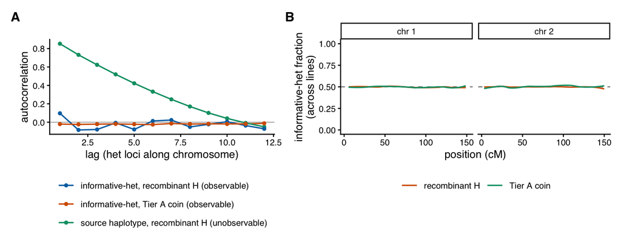

```r
# lag profile, averaged over lines and chromosomes, for the three layers
lag_profile <- function(seqs, lab, maxlag = 12L) {
  acc <- matrix(NA_real_, 0, maxlag + 1L)
  for (byline in seqs) {
    for (v in byline) {
      if (length(v) > maxlag + 2L && sd(v) > 0) {
        acc <- rbind(acc, acf(v, lag.max = maxlag, plot = FALSE)$acf[, 1, 1])
      }
    }
  }
  data.table(lag = 0:maxlag, acf = colMeans(acc, na.rm = TRUE), series = lab)
}
prof <- rbindlist(list(
  lag_profile(seq_src, "source haplotype, recombinant H (unobservable)"),
  lag_profile(seq_infR, "informative-het, recombinant H (observable)"),
  lag_profile(seq_infC, "informative-het, Tier A coin (observable)")
))[lag > 0]
pA <- ggplot(prof, aes(lag, acf, colour = series)) +
  geom_hline(yintercept = 0, linewidth = 0.3, colour = "grey60") +
  geom_line(linewidth = 0.6) +
  geom_point(size = 1.2) +
  scale_colour_manual(values = c("#0072B2", "#D55E00", "#009E73")) +
  labs(
    x = "lag (het loci along chromosome)", y = "autocorrelation",
    colour = NULL, tag = "A"
  ) +
  theme(legend.position = "bottom", legend.direction = "vertical")

# density + spatial uniformity of the informative-het indicator
dens <- data.table(
  chr = markers$chr, cm = markers$cm, is_het = is_het,
  recombinant = dens_hard / N, coin = dens_coin / N
)[is_het == TRUE]
densL <- melt(dens, id.vars = c("chr", "cm"), measure.vars = c("recombinant", "coin"),
  variable.name = "model", value.name = "informative_frac"
)
densL[, model := factor(model,
  labels = c("recombinant H", "Tier A coin")
)]
pB <- ggplot(densL, aes(cm, informative_frac, colour = model)) +
  geom_hline(yintercept = 0.5, linetype = "dashed", colour = "grey50") +
  geom_smooth(se = FALSE, linewidth = 0.6, method = "loess", span = 0.4) +
  facet_wrap(~chr, nrow = 1, labeller = labeller(chr = function(x) paste("chr", x))) +
  scale_colour_manual(values = c("#D55E00", "#009E73")) +
  ylim(0, 1) +
  labs(
    x = "position (cM)", y = "informative-het fraction\n(across lines)",
    colour = NULL, tag = "B"
  ) +
  theme(legend.position = "bottom")

pA + pB + plot_layout(widths = c(1, 1.2))
```

Panel A: the source-haplotype indicator (recombinant H) is strongly autocorrelated, the real Mb-scale meiotic blocks. Both observable informative-het indicators, the true recombinant and the Tier A coin, sit at ~0 autocorrelation: the block structure does not appear in what the caller sees. Panel B: the informative-het fraction is ~0.5 and spatially uniform under both models, because the donor’s two haplotypes are complementary at het sites, so whichever haplotype the gamete carries, ~half the het loci are informative.

## Conclusion

```r
cat(sprintf(
  paste0(
    "Claim 1  factorization mismatches ....... %d (PASS: exact)\n",
    "Claim 2a het-locus genotype max |dfreq| .. %.4f (recombinant H vs Tier A coin)\n",
    "Claim 2b lag-1 autocorrelation:\n",
    "         source haplotype (recombinant) .. %.3f  (real, unobservable blocks)\n",
    "         informative-het (recombinant) ... %.3f  (observable: ~0)\n",
    "         informative-het (Tier A coin) ... %.3f  (observable: ~0, matches)\n"
  ),
  mismatch, max(abs(fh - fc)),
  mean_lag1(seq_src), mean_lag1(seq_infR), mean_lag1(seq_infC)
))
```

```
Claim 1  factorization mismatches ....... 0 (PASS: exact)
Claim 2a het-locus genotype max |dfreq| .. 0.0001 (recombinant H vs Tier A coin)
Claim 2b lag-1 autocorrelation:
         source haplotype (recombinant) .. 0.853  (real, unobservable blocks)
         informative-het (recombinant) ... 0.097  (observable: ~0)
         informative-het (Tier A coin) ... -0.021  (observable: ~0, matches)
```

The single-donor NIL genotype is `ancestry_dose x X` exactly, so the two-stage `simulate_zeal_pool.R` construction (simcross ancestry, then paint the founding allele) tracks allelic inheritance correctly without a separate allele tree. And at SNP50K spacing the Tier A i.i.d. het coin is not merely a convenient approximation: it reproduces the observed genotype distribution of the true recombinant founding gamete, marginally and in autocorrelation, because the only structure it discards (which donor haplotype is the source) is unobservable at this marker density. The gain a phased Tier B would add is confined to that hidden layer.